# Problem Set 2

Author

Xiuyu Cao

Published

April 15, 2024

```r
library(tidyverse)
library(car)
```

# 1 Question 1

```r
data1 <- read.csv('../data/problemset2/data_q1.csv')
```

## 1.1 A

- $H_0:$ There is **no** difference in student’s heart rate when opening up R studio before and after taking EAS 538.
- $H_A:$ There **is** a difference in student’s heart rate when opening up R studio before and after taking EAS 538.

## 1.2 B

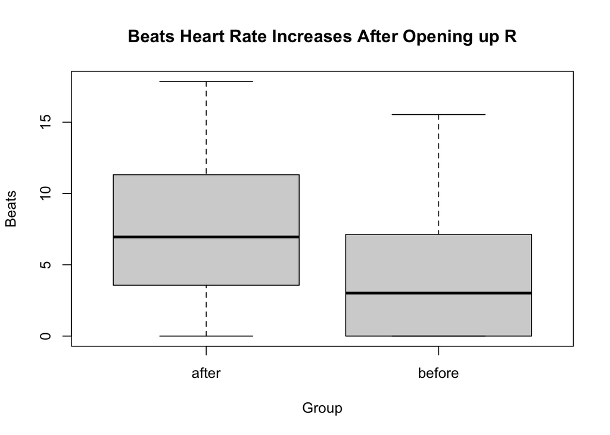

```r
boxplot(rate~when, data=data1,
        xlab='Group', ylab='Beats',
        main='Beats Heart Rate Increases After Opening up R')
```

From the box plot, the mean of group “after” seems higher than the group “before”.

## 1.3 C

According to the information, I will be using paired t-test.

For checking the t-test assumptions, first convert the data to one-sample, calculating differences of each pair `data1.diff`.

```r
data1.wide <- data1 %>%
  pivot_wider(names_from=when, values_from=rate) %>%
  mutate(diff=after-before)
head(data1.wide)
```

```
# A tibble: 6 × 4
  student before after    diff
    <int>  <dbl> <dbl>   <dbl>
1       1   0     5.14   5.14
2       2  12.4  17.2    4.72
3       3   2.31  0     -2.31
4       4   5.06  4.11  -0.949
5       5   2.08  9.49   7.41
6       6  15.5   0    -15.5
```

Then check one-sample t-test assumptions

```r
## Normality
dim(data1.wide)
```

```
[1] 60  4
```

```r
shapiro.test(data1.wide$diff)
```

```
    Shapiro-Wilk normality test

data:  data1.wide$diff
W = 0.97299, p-value = 0.2038
```

## 1.4 D

```r
t.test(data1.wide$after, data1.wide$before, paired=T)
```

```
    Paired t-test

data:  data1.wide$after and data1.wide$before
t = 4.2214, df = 59, p-value = 8.502e-05
alternative hypothesis: true mean difference is not equal to 0
95 percent confidence interval:
 1.709315 4.790146
sample estimates:
mean difference
       3.249731
```

**Result Interpretation:** From the result of the paired t-test, $P=8.5\times10^{-5}<\alpha=0.05$. We thus reject $H_0$, and we can say that there is a significant difference in student’s heart rate when opening up R studio before and after taking EAS 538. The mean beats increased of the after group is significantly higher than the before one.

# 2 Question 2

```r
data2 <- read.csv('../data/problemset2/data_q2.csv') %>%
  mutate(type=as.factor(type)) %>%
  mutate(paid=as.factor(paid))
head(data2, 3)
```

```
    type paid users comment like share
1  Photo    0   178       4   79    17
2 Status    0  1457       5  130    29
3  Photo    0   177       0   66    14
```

## 2.1 A

According to the information, I will be running a linear regression model.

First check multicollinearity.

```r
cor(data2[,3:5])
```

```
            users   comment      like
users   1.0000000 0.4139077 0.4827045
comment 0.4139077 1.0000000 0.6606773
like    0.4827045 0.6606773 1.0000000
```

```r
vif(lm(share~type+paid+users+comment+like, data=data2))
```

```
            GVIF Df GVIF^(1/(2*Df))
type    1.326783  3        1.048254
paid    1.024481  1        1.012166
users   1.741348  1        1.319601
comment 1.820190  1        1.349144
like    2.033110  1        1.425872
```

## 2.2 B

- $H_0:$ There is no significant relationship between share number and all the other factors.
- $H_A:$ There is significant relationship between share number one or more of the factors.

## 2.3 C

I am using linear regression.

Check the assumptions.

First check the distribution of the dependent variable to get an idea of how the residuals will be like.

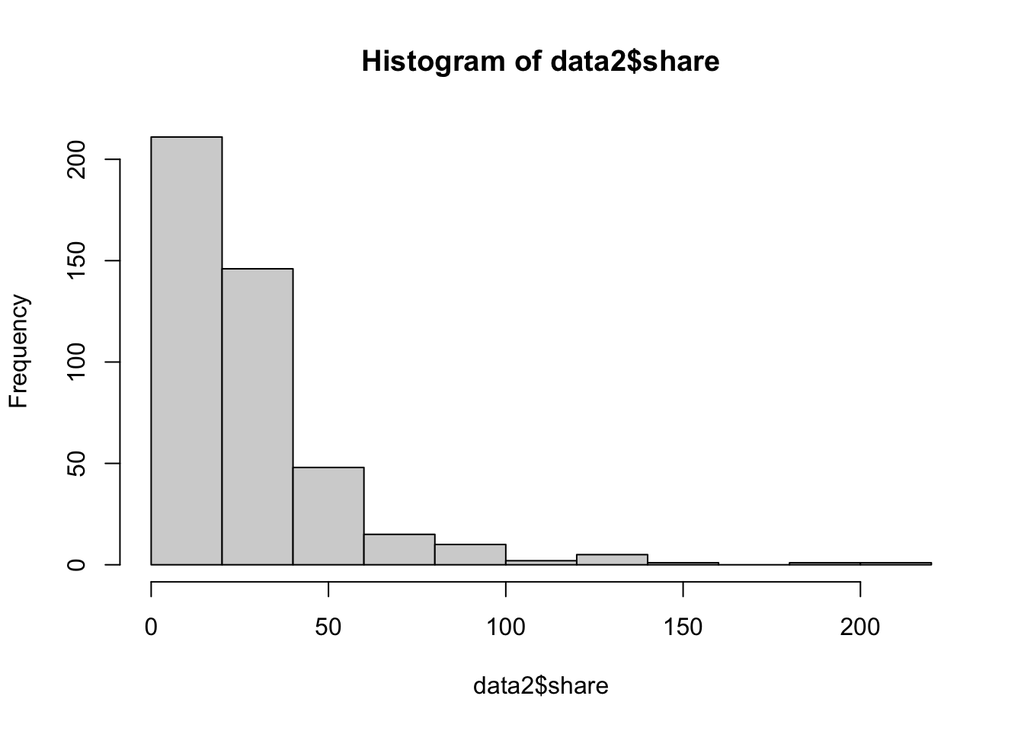

```r
hist(data2$share)
```

Looks not good. I would do a log transform.

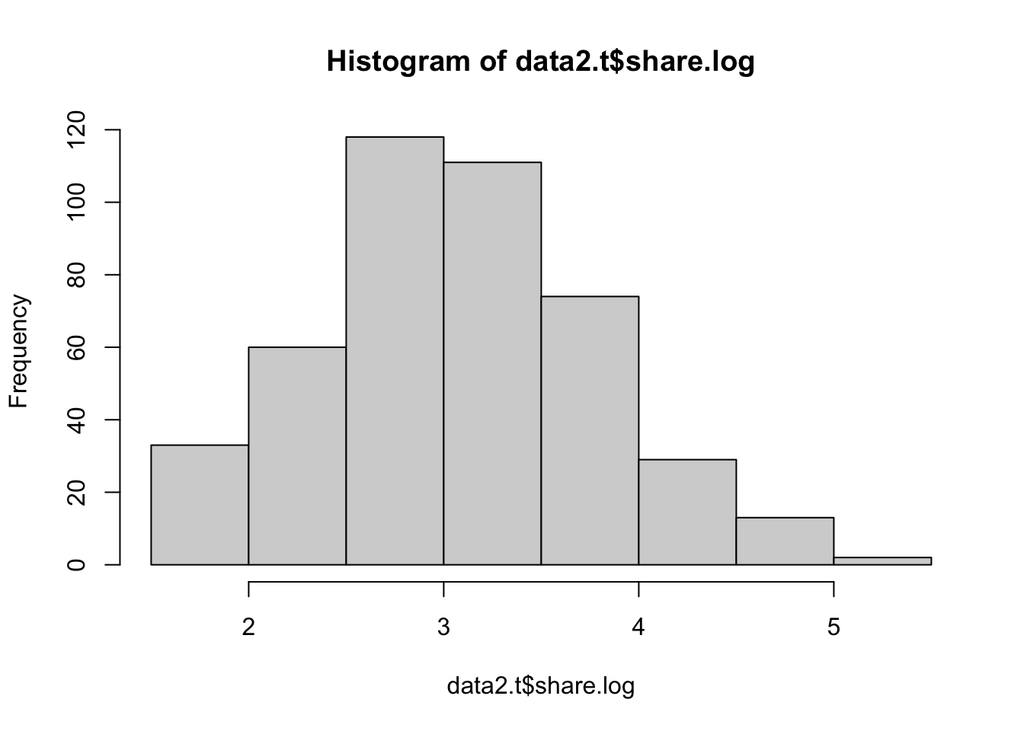

```r
data2.t <- data2 %>%
  mutate(share.log=log(share))
hist(data2.t$share.log)
```

Looks good now. Then check linear regression assumptions.

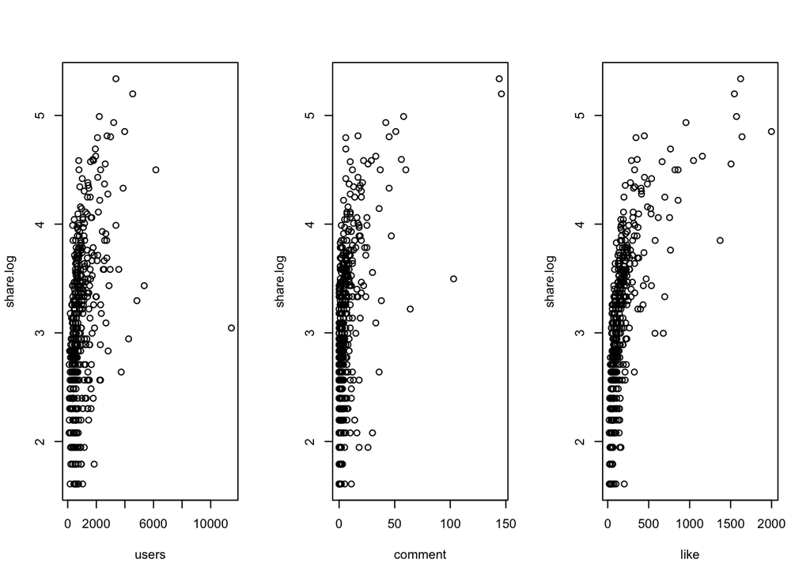

```r
# get linear model
lmod <- lm(share.log~users+comment+like+type+paid, data=data2.t)

## linear relationship
par(mfrow=c(1,3))
plot(share.log~users, data=data2.t)
plot(share.log~comment, data=data2.t)
plot(share.log~like, data=data2.t)
```

```r
## homoscedasticity
ncvTest(lmod)
```

```
Non-constant Variance Score Test
Variance formula: ~ fitted.values
Chisquare = 12.96021, Df = 1, p = 0.00031818
```

```r
## residual normality
shapiro.test(residuals(lmod))
```

```
    Shapiro-Wilk normality test

data:  residuals(lmod)
W = 0.98876, p-value = 0.001874
```

**Linear Regression Assumptions:**

- There is a linear relationship between the variables - From the plots, met.
- Statistical independence of the errors - Assume so.
- Homoscedasticity - $P=0.0003<\alpha=0.05$, reject ncvTest $H_0:$ *constant variance.* Therefore, the assumption of homoscedasticity is not met.
- Residual normality - $P=0.001<\alpha=0.05$, reject Shapiro test $H_0:$ *Normally distributed.* Therefore, the assumption of residual normality is not met.

## 2.4 D

```r
summary(lmod)
```

```
Call:
lm(formula = share.log ~ users + comment + like + type + paid,
    data = data2.t)

Residuals:
     Min       1Q   Median       3Q      Max
-1.53962 -0.36000  0.03511  0.39555  1.28918

Coefficients:
              Estimate Std. Error t value Pr(>|t|)
(Intercept)  2.444e+00  1.340e-01  18.232  < 2e-16 ***
users        4.450e-05  3.583e-05   1.242  0.21498
comment      3.046e-03  2.496e-03   1.220  0.22301
like         1.712e-03  1.539e-04  11.124  < 2e-16 ***
typePhoto    2.542e-01  1.362e-01   1.867  0.06263 .
typeStatus   4.357e-01  1.672e-01   2.606  0.00949 **
typeVideo    6.682e-01  2.487e-01   2.687  0.00749 **
paid1       -6.029e-02  5.860e-02  -1.029  0.30410
---
Signif. codes:  0 '***' 0.001 '**' 0.01 '*' 0.05 '.' 0.1 ' ' 1

Residual standard error: 0.5461 on 431 degrees of freedom
  (1 observation deleted due to missingness)
Multiple R-squared:  0.4409,    Adjusted R-squared:  0.4318
F-statistic: 48.55 on 7 and 431 DF,  p-value: < 2.2e-16
```

**Result Interpretation: (at $\alpha=0.05$)**

- `Intercept`($P<\alpha$): With `users`, `comment`, `like` being zero and `paid` being unpaid, it is predicted that there will be 2.44 log shares on average if the content is a link.
- `users`, `comment`($P>\alpha$): There is no significant linear relationship between `users`/`comment` and log share.
- `like`($P<\alpha$): Every one like increased is associated with an increase of $1.7\times10^{-3}$ log shares.
- `typePhoto`($P>\alpha$): No significant difference in log shares between photo and link contents when unpaid, controlling for `users`, `comment`, and `like`.
- `typeStatus`($P<\alpha$): On average, status contents have 0.4 more log shares than link contents when unpaid, controlling for `users`, `comment`, and `like`.
- `typeVideo`($P<\alpha$): On average, video contents have 0.7 more log shares than link contents when unpaid, controlling for `users`, `comment`, and `like`.
- `paid1`($P>\alpha$): No significant difference in log shares between paid and unpaid link contents, controlling for `users`, `comment`, and `like`.

## 2.5 E

The adjusted R-squared is 0.43, which means the independent variables in the model explains 43% of the variation in the log share. We also have the P-value of F-statistic $2.2\times10^{-16}<\alpha=0.05$, we can reject $H_0:$ *no significant relationship*. Therefore, I would say this is a good fit.

# 3 Question 3

```r
data3 <- read.csv('../data/problemset2/data_q3.csv') %>%
  mutate(Type=as.factor(Type))
head(data3, 3)
```

```
  Type Calories
1 beef 142.7532
2 beef 148.1573
3 beef 160.2559
```

## 3.1 A

- $H_0:$ There is no difference in the number of calories among the three types of hot dog.
- $H_1:$ At least one of the types of hot dog differ in calories from others.

## 3.2 B

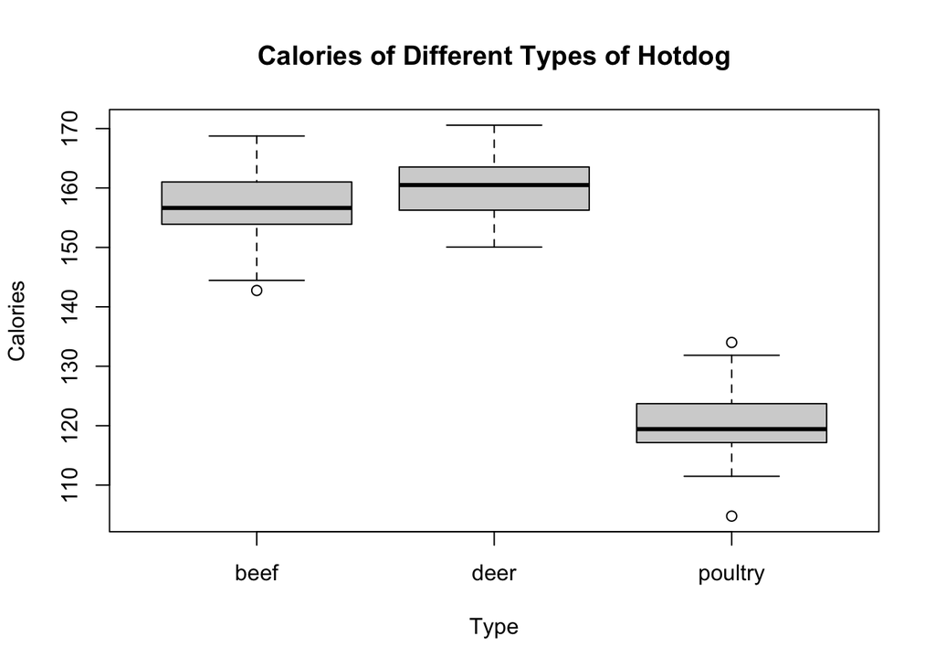

```r
boxplot(Calories~Type, data=data3,
        main='Calories of Different Types of Hotdog')
```

From the box plot, poultry hotdog seems differs in calories from the other two.

## 3.3 C

I will be using ANOVA

Check ANOVA assumptions

```r
# Equal Variance
leveneTest(Calories~Type, data3, center=mean)
```

```
Levene's Test for Homogeneity of Variance (center = mean)
       Df F value Pr(>F)
group   2   0.923 0.3996
      147
```

```r
# Normality
beef <- filter(data3, Type=='beef')
deer <- filter(data3, Type=='deer')
poultry <- filter(data3, Type=='poultry')

dim(beef)
```

```
[1] 50  2
```

```r
dim(deer)
```

```
[1] 50  2
```

```r
dim(poultry)
```

```
[1] 50  2
```

```r
shapiro.test(beef$Calories)
```

```
    Shapiro-Wilk normality test

data:  beef$Calories
W = 0.97035, p-value = 0.2392
```

```r
shapiro.test(deer$Calories)
```

```
    Shapiro-Wilk normality test

data:  deer$Calories
W = 0.97698, p-value = 0.4329
```

```r
shapiro.test(poultry$Calories)
```

```
    Shapiro-Wilk normality test

data:  poultry$Calories
W = 0.97461, p-value = 0.3525
```

**Conclusion:**

- Continuous response data - Met
- Samples must be independent - Assume so
- Each population must have the same variance - from the output of the `leveneTest()`, $P=0.4>\alpha=0.05$. We thus fail to rejct $H_0:$ *Equal variance.* Therefore, the assumption is met.
- The populations of interest must be normally distributed - From the outputs of the `shapiro.test()` of each type, all of the p values $>\alpha=0.05$. We thus fail to reject $H_0:$ *The input scores are normally distributed*. Therefore, the AVOVA’s normality assumption is met.

## 3.4 D

```r
aov <- aov(Calories~Type, data=data3)
summary(aov)
```

```
             Df Sum Sq Mean Sq F value Pr(>F)
Type          2  48793   24397   763.3 <2e-16 ***
Residuals   147   4698      32
---
Signif. codes:  0 '***' 0.001 '**' 0.01 '*' 0.05 '.' 0.1 ' ' 1
```

```r
# Post hoc test
TukeyHSD(aov)
```

```
  Tukey multiple comparisons of means
    95% family-wise confidence level

Fit: aov(formula = Calories ~ Type, data = data3)

$Type
                   diff          lwr        upr    p adj
deer-beef      2.626561  -0.05051553   5.303638 0.055747
poultry-beef -36.878723 -39.55580019 -34.201647 0.000000
poultry-deer -39.505285 -42.18236148 -36.828208 0.000000
```

**Result Interpretation:**

- From the output of `aov()`, the p value is $2\times10^{-16}<\alpha=0.05.$ We thus reject $H_0$, we can say that at least one of the types has different mean calories comparing to the others.
- From the output of `dim()`, the three groups are of the same size, we can then do the Tukey’s HSD test. From the output of `TukeyHSD()`, calories of poultry is significantly smaller than that of beef ($P=0<\alpha=0.05$), calories poultry is significantly smaller than that of deer ($P=0<\alpha=0.05$).

# 4 Question 4

```r
data4 <- read.csv('../data/problemset2/data_q4.csv') %>%
  mutate(cactus.type=as.factor(cactus.type))
head(data4, 3)
```

```
  sucrose weight days.old cactus.type
1       5  21.65       52        Wild
2       7  20.29       52      Blanco
3       6  28.61       52      Blanco
```

## 4.1 A

I will be using linear regression, `sucrose` ~ `weight` + `days.old` + `cactus.type`

## 4.2 B

Check multicollinearity

```r
cor(data4[,2:3])
```

```
              weight    days.old
weight    1.00000000 -0.09902604
days.old -0.09902604  1.00000000
```

```r
vif(lm(sucrose ~ weight + days.old + cactus.type, data=data4))
```

```
                GVIF Df GVIF^(1/(2*Df))
weight      1.587287  1        1.259876
days.old    1.174890  1        1.083923
cactus.type 1.694358  3        1.091861
```

Similar to quesiont 2, nothing to worry about.

Then check linear regression assumptions. First check the distribution of the dependent variable.

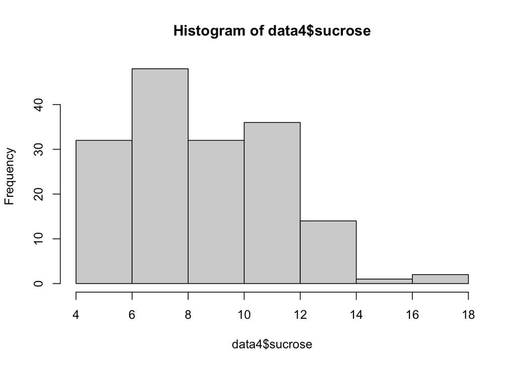

```r
hist(data4$sucrose)
```

Looks not good. Log it.

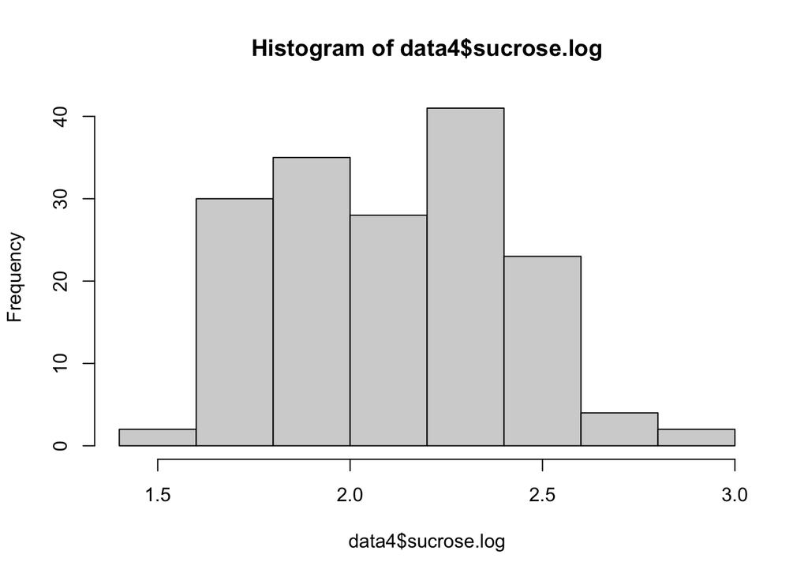

```r
data4 <- data4 %>%
  mutate(sucrose.log=log(sucrose))
hist(data4$sucrose.log)
```

Looks good. Fit the model and check assumptions.

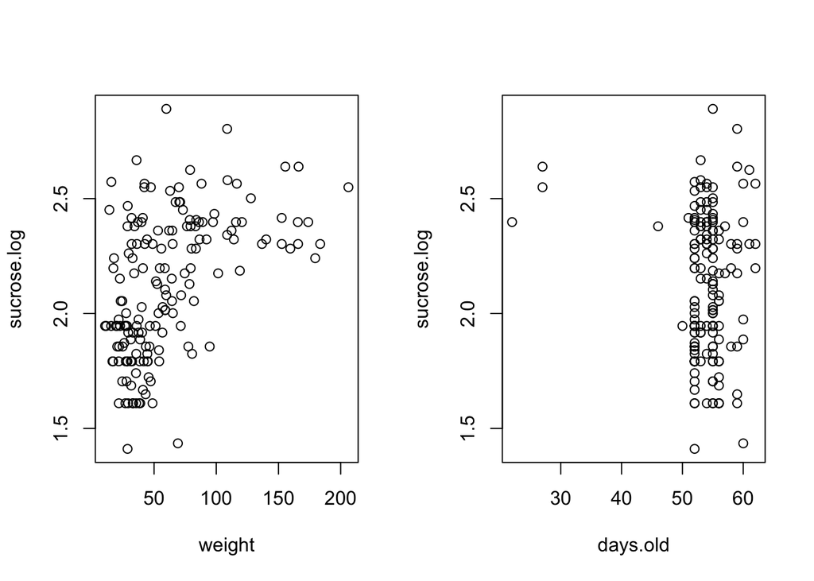

```r
lmod <- lm(sucrose.log~weight+days.old+cactus.type, data=data4)

## Linear relationship
par(mfrow=c(1,2))
plot(sucrose.log~weight, data=data4)
plot(sucrose.log~days.old, data=data4)
```

```r
## homoscedasticity
ncvTest(lmod)
```

```
Non-constant Variance Score Test
Variance formula: ~ fitted.values
Chisquare = 0.01017772, Df = 1, p = 0.91964
```

```r
## residual normality
shapiro.test(residuals(lmod))
```

```
    Shapiro-Wilk normality test

data:  residuals(lmod)
W = 0.99057, p-value = 0.3457
```

**Linear Regression Assumptions:**

- There is a linear relationship between the variables - From the plots, met.
- Statistical independence of the errors - Assume so.
- Homoscedasticity - $P=0.92>\alpha=0,05$, fail to reject ncvTest $H_0:$ *constant variance.* Therefore, the assumption of homoscedasticity is met.
- Residual normality - $P=0.34>\alpha=0.05$, fail to reject Shapiro test $H_0:$ *Normally distributed.* Therefore, the assumption of residual normality is met.

## 4.3 C

```r
summary(lmod)
```

```
Call:
lm(formula = sucrose.log ~ weight + days.old + cactus.type, data = data4)

Residuals:
     Min       1Q   Median       3Q      Max
-0.67255 -0.19041  0.00752  0.17672  0.71719

Coefficients:
                       Estimate Std. Error t value Pr(>|t|)
(Intercept)            1.801065   0.251604   7.158 2.84e-11 ***
weight                 0.004866   0.000615   7.912 4.04e-13 ***
days.old               0.003099   0.004576   0.677  0.49915
cactus.typeMamey      -0.215908   0.077380  -2.790  0.00591 **
cactus.typeTenamaxtle -0.255828   0.057652  -4.437 1.69e-05 ***
cactus.typeWild       -0.089505   0.056200  -1.593  0.11323
---
Signif. codes:  0 '***' 0.001 '**' 0.01 '*' 0.05 '.' 0.1 ' ' 1

Residual standard error: 0.2537 on 159 degrees of freedom
Multiple R-squared:  0.337, Adjusted R-squared:  0.3161
F-statistic: 16.16 on 5 and 159 DF,  p-value: 7.192e-13
```

**Result Interpretation: (at $\alpha=0.05$)**

- `Intercept`($P<\alpha$): With `weight` and `days.old` being zero, it is predicted that there will be 1.8 log percent sucrose on average in type Blanco.
- `weight`($P<\alpha$): Every one gram increased in weight is associated with an increase of 0.005 log percent sucrose.
- `days.old`: There is no significant linear relationship between `days.old` and log percent sucrose.
- `cactus.typeMamey`($P<\alpha$): On average, Mamey cactus have 0.2 less log percent sucrose than Blanco, controlling for `weight` and `days.old`.
- `cactus.typeTenamaxtle`($P<\alpha$): On average, Tenamaxtle cactus have 0.26 less log percent sucrose than Blanco, controlling for `weight` and `days.old`.
- `cactus.typeWild`($P>\alpha$): No significant difference in log percent sucrose between typeWild and Blanco, controlling for `weight` and `days.old`.

## 4.4 D

```r
lmod2 <- lm(sucrose.log~weight+cactus.type*days.old, data=data4)
summary(lmod2)
```

```
Call:
lm(formula = sucrose.log ~ weight + cactus.type * days.old, data = data4)

Residuals:
     Min       1Q   Median       3Q      Max
-0.67409 -0.16381 -0.00898  0.15884  0.70751

Coefficients:
                                 Estimate Std. Error t value Pr(>|t|)
(Intercept)                    -1.3501814  1.4811147  -0.912  0.36339
weight                          0.0043768  0.0006193   7.068 4.94e-11 ***
cactus.typeMamey                3.1640960  1.4915144   2.121  0.03547 *
cactus.typeTenamaxtle           5.8437690  2.1852619   2.674  0.00829 **
cactus.typeWild                -2.0786402  2.2341812  -0.930  0.35361
days.old                        0.0637145  0.0282364   2.256  0.02543 *
cactus.typeMamey:days.old      -0.0638379  0.0284725  -2.242  0.02637 *
cactus.typeTenamaxtle:days.old -0.1135201  0.0405437  -2.800  0.00576 **
cactus.typeWild:days.old        0.0367754  0.0423844   0.868  0.38691
---
Signif. codes:  0 '***' 0.001 '**' 0.01 '*' 0.05 '.' 0.1 ' ' 1

Residual standard error: 0.2428 on 156 degrees of freedom
Multiple R-squared:  0.4046,    Adjusted R-squared:  0.374
F-statistic: 13.25 on 8 and 156 DF,  p-value: 1.633e-14
```

**How the relationships between log sucrose and days.old differ across varieties ($\alpha=0.05$)**

## 4.5 E

```r
# visualize
range(data4$days.old)
```

```
[1] 22 62
```

```r
range(data4$sucrose.log)
```

```
[1] 1.410987 2.890372
```

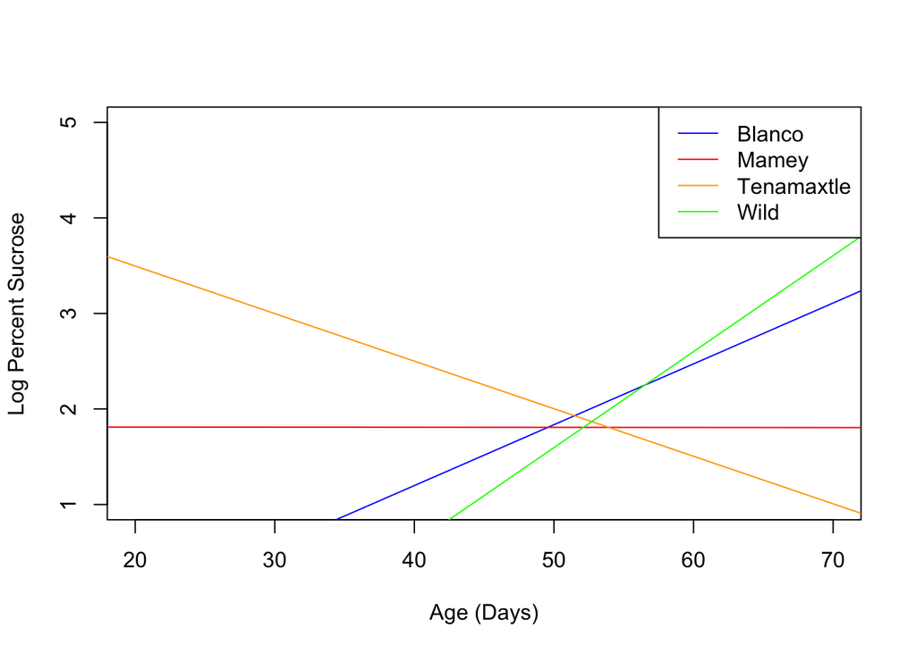

```r
plot(1:1000, rep(-100, 1000), ylim = c(1, 5), xlim = c(20, 70), xlab = 'Age (Days)', ylab = 'Log Percent Sucrose')
abline(a = -1.3501814, b = 0.0637145, col = 'blue') # Blanco
abline(a = -1.3501814 + 3.1640960, b = 0.0637145 -0.0638379, col = 'red') # Mamey
abline(a = -1.3501814 + 5.8437690 , b = 0.0637145 -0.1135201, col = 'orange') # Tenamaxtle
abline(a = -1.3501814 - 2.0786402, b = 0.0637145 + 0.0367754, col = 'green') # Wild
legend("topright", legend=c("Blanco", "Mamey", "Tenamaxtle", "Wild"),
       col=c("blue", "red", "orange", "green"), lty=1)
```

# 5 Extra Credits

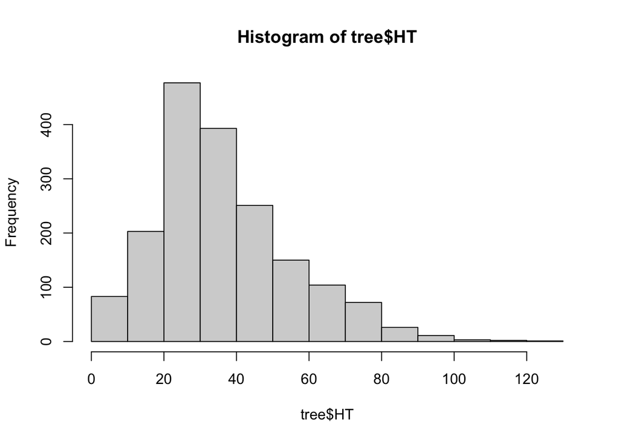

```r
library(nlme)
## get data
library(FIESTA)  # Forest Inventory data
tree <- WYtree %>%  # Trees in WY
  filter(STATUSCD==1) %>%  # living tree
  filter(SPGRPCD>=1, SPGRPCD<=24) %>%  # softwood species groups
  filter(SPCD==101 | SPCD==113 | SPCD==202) %>%  # softwood species code 101, 113, and 202
  select(SPCD, DIA, HT) %>%  # species code, diameter (inches), and height (feet)
  mutate(SPCD=as.factor(SPCD))


hist(tree$HT)
```

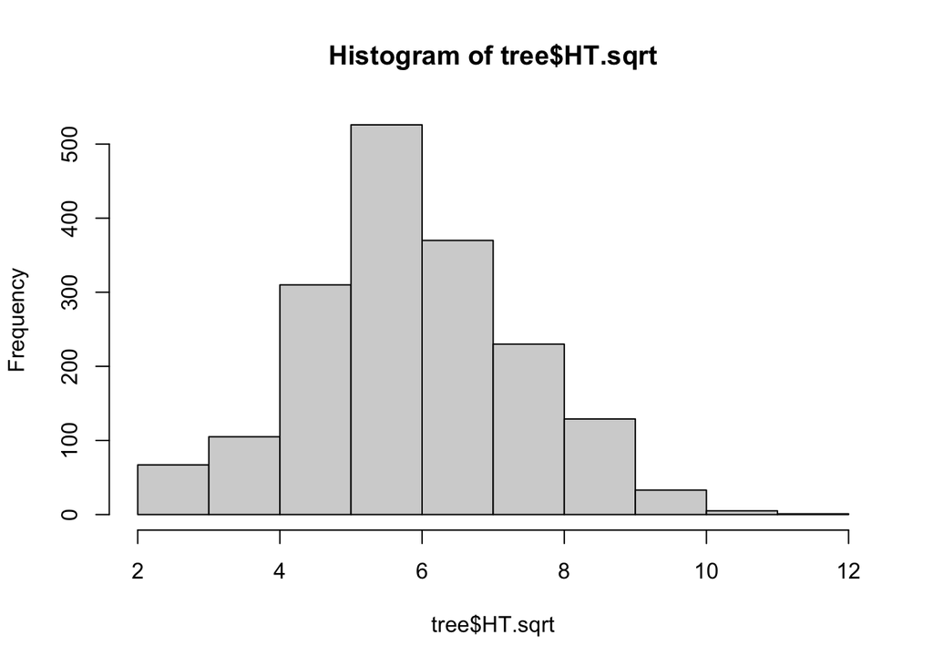

```r
tree <- tree %>%
  mutate(HT.sqrt=sqrt(HT))
hist(tree$HT.sqrt)
```

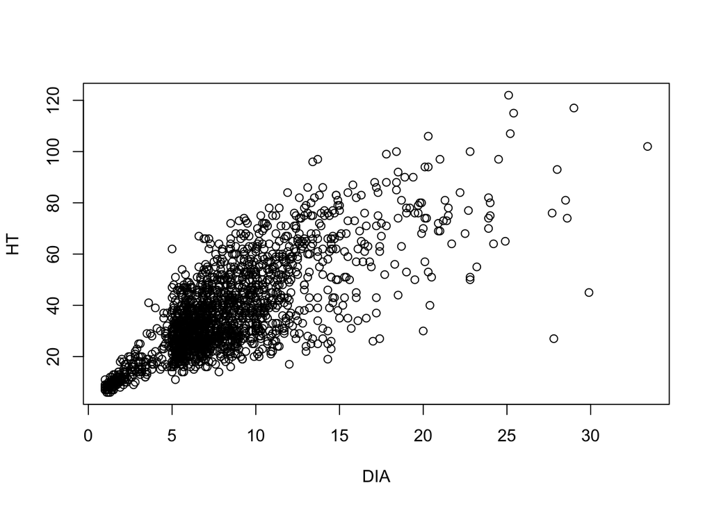

```r
lmod <- lme(HT.sqrt ~ DIA, random = ~1|SPCD, data=tree)
## assumptions
# linear relationship -met
plot(HT~DIA, data=tree)
```

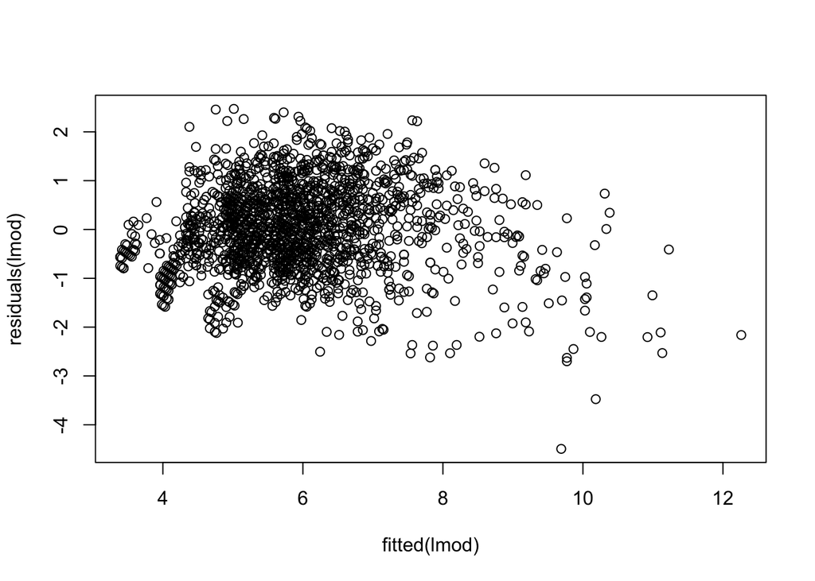

```r
# homoscedasticity - not met
plot(residuals(lmod)~fitted(lmod), data=tree)
```

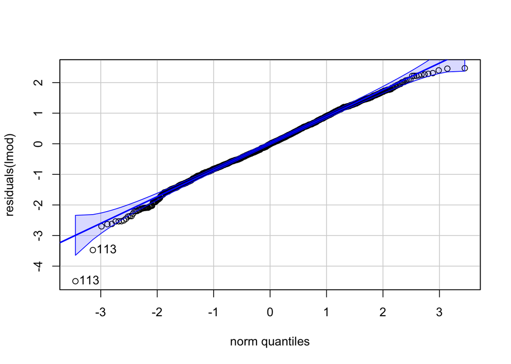

```
113 113
399 690
```

```r
# normality - met
qqPlot(residuals(lmod))
```

```r
# statistical independence of errors - Assume so

summary(lmod)
```

```
Linear mixed-effects model fit by REML
  Data: tree
       AIC      BIC    logLik
  4610.991 4632.915 -2301.495

Random effects:
 Formula: ~1 | SPCD
        (Intercept)  Residual
StdDev:   0.6300698 0.8783189

Fixed effects:  HT.sqrt ~ DIA
               Value Std.Error   DF  t-value p-value
(Intercept) 3.765911 0.3666416 1772 10.27137       0
DIA         0.234982 0.0049315 1772 47.64946       0
 Correlation:
    (Intr)
DIA -0.107

Standardized Within-Group Residuals:
        Min          Q1         Med          Q3         Max
-5.11597971 -0.65085614 -0.01092235  0.68981652  2.81200068

Number of Observations: 1776
Number of Groups: 3
```